# S10_ Estudio de los factores en el rendimiento, calidad de vida y salud mental del estudiante UTEC en el ciclo 2023-I según la música o tipo de instrumento musical de preferencia

31 Agosto, 2023

# **INTRODUCCIÓN**

## **Relevancia y objetivos:**

- Comparar y analizar el impacto que genera el conocimiento de un tipo de instrumento musical o el tipo de música que escuchan en el aprendizaje universitario de los estudiantes UTEC que están cursando el periodo 2023-I.
- Identificar si el aprendizaje de instrumentos musicales mejora la calidad de vida, los niveles de estrés y la salud mental del estudiante.
- Animar y motivar el aprendizaje de un instrumento musical en el estudiante. De esta manera estaríamos impulsando aún más la educación musical en la universidad.

## **Planificación:**

Nuestra planificación para la PG1-avance1 y PG1-avance2 se basó en dividir en la creación del forms y la presentación en R. Una parte del grupo ideó las preguntas según nuestras variables encontradas y la otra parte se encarga de programar la presentación en R. Asimismo, uno se encarga de realizar la introducción y los datos , y para la PG1-avance3 la otra persona realizará el análisis descriptivo cuando los datos sean recolectados. Esto se decidió porque no todos poseemos el mismo dominio de este lenguaje de programación y siempre es bueno optimizar el tiempo a nuestro favor.

El informe ha sido realizado en un plazo de 4 días entre el martes 30/05/2023 y el viernes 02/06/2023. No ha sido tan tedioso ya que poseemos todos lo avances en Rmarkdown presentation y solo tuvimos que pasarlo a Rnotebook.

# **DATOS**

## Recolección de datos

- La recolección de los datos se realizará mediante un formulario-encuesta en google forms, todo se guardará en nuestro archivo csv llamado DATA_BASE_EyP_PG5.csv. Estará divido en 3 tablas: Aquellos que tocan instrumentos, aquellos que no y los datos de entrada.

## TABLA DE VARIABLES

### DATOS DE ENTRADA:

| PREGUNTA | Nombre de variable | Tipo de variable | Restricciones |
| --- | --- | --- | --- |
| ¿Cuál es tu edad? | edad | Numérica Discreta | Entero positivo. |
| ¿Cuál es tu género? | sexo | Categórica Nominal | Hombre o mujer. |
| ¿Qué carrera estás estudiando en UTEC? | carrera | Categórica Nominal | Carrera que estudia. |
| ¿Qué ciclo estás cursando? | ciclo | Numérica Discreta | 1-10 , primer a décimo. |
| ¿Tocas algún instrumento musical? | tocan_instrumento | Categórica Nominal | Sí o No. |

### TOCAN INSTRUMENTOS:

| PREGUNTA | Nombre de variable | Tipo de variable | Restricciones |
| --- | --- | --- | --- |
| ¿Qué tipo de instrumentos tocas? | tipo_instrumento | Categórica Nominal | Opciones. |
| ¿Cuántas horas a la semana dedicas a estudiar tus cursos en UTEC? (fuera del tiempo académico) | horas_estudio | Numérica Discreta | Entero positivo. |
| ¿Cuánto tiempo a la semana dedicas a practicar tu instrumento musical? | horas_instrumento | Numérica Discreta | Entero positivo. |
| ¿Cómo calificarías tu nivel de habilidad para tocar tu instrumento musical? | habilidad | Numérica Discreta | Muy poco habilidoso - Muy habilidoso (1-5) |
| ¿Qué tan importante crees que es la música en tu vida? | importancia | Numérica Discreta | Muy poco habilidoso - Muy habilidoso (1-5) |
| ¿Has tocado algún instrumento musical en alguna presentación en vivo o en un grupo musical? | tocar_en_vivo? | Categórica Nominal | Sí o No. |
| ¿Cómo te sientes cuando estás tocando tu instrumento musical? | sentimiento | Categórica Nominal | Desde indiferente hasta distintas emociones(5) |
| ¿De qué manera un instrumento musical te ha ayudado en tu desempeño académico? | desempeño_academico | Categórica Ordinal. | Desde nada importante hasta muy benificioso (1-5) |
| ¿Qué tan importante crees que es tocar un instrumento musical para mejorar tu desempeño académico? | salud_mental | Categórica Ordinal. | Desde nada importante hasta muy benificioso (1-5) |
| ¿Cuál es el instrumento musical que dominas? | instrumento_dominante | Categórica Nominal. | Escribir. |
| ¿Cuánto tiempo llevas tocando ese instrumento musical? | tiempo_tocando | Numérica Discreta | Entero positivo. |
| ¿Qué beneficios crees que tiene el tocar un instrumento musical en tu vida? | beneficios | Categórica Nominal | Opciones. |

### NO TOCAN INSTRUMENTOS:

| PREGUNTA | Nombre de variable | Tipo de variable | Restricciones |
| --- | --- | --- | --- |
| ¿Qué tipo de música sueles escuchar con más frecuencia? | tipo_musica | Categórica Nominal | Opciones. |
| ¿Cuántas horas a la semana dedicas a estudiar tus cursos en UTEC? (fuera del tiempo académico) | horas_estudio | Numérica Discreta | Entero positivo. |
| ¿Cuántas horas al día sueles escuchar música? | horas_musica | Numérica Continua | Real positivo. |
| ¿Qué tan importante crees que es la música en tu vida? | importancia | Numérica Discreta | Del 1 al 5. |
| ¿Cuál es tu género de música favorito para relajarte? | genero_relajacion | Categórica Nominal | Opciones. |
| ¿Cuál es tu género de música favorito para motivarte? | genero_motivacion | Categórica Nominal | Opciones. |
| ¿Cómo calificarías tu nivel de concentración cuando escuchas música? | concentracion | Numérica Discreta | 1 al 5. |
| ¿Crees que el tipo de música que escuchas afecta tu estado de ánimo? | animo | Categórica Nominal. | Sí o No. |
| ¿Crees que el escuchar música te ayuda a reducir el estrés? | estres | Categórica Nominal. | Sí o No. |
| ¿En qué momento(s) del día sueles escuchar música? | momentos | Categórica Nominal. | Escribir. |
| ¿Qué beneficios crees que tiene el escuchar música en tu vida? | beneficios | Categórica Ordinal | Desde nada importante hasta muy benificioso (5) |

## Limpieza de los datos

Veamos los nombres de nuestros datos

```r
names(DATOS)
```

```
## [1] "edad"               "sexo"               "carrera"
## [4] "ciclo"              "tocan_instrumentos"
```

```r
names(DATOS_TOCAN)
```

```
##  [1] "tipo_instrumento"      "horas_estudio"         "horas_instrumento"
##  [4] "habilidad"             "importancia"           "tocar_en_vivo?"
##  [7] "sentimiento"           "desempeño_academico"   "salud_mental"
## [10] "instrumento_dominante" "tiempo_tocando"        "beneficios"
```

```r
names(DATOS_NO_TOCAN)
```

```
##  [1] "tipo_musica"       "horas_estudio"     "horas_musica"
##  [4] "importancia"       "genero_relajacion" "genero_motivacion"
##  [7] "concentracion"     "animo"             "estres"
## [10] "momentos"          "beneficios"
```

Primero corregiremos los tipos de algunas variables que han sido registradas de forma errónea.

La primera tabla (**Datos de entrada**) y la tercera tabla (**No tocan instrumentos**) tienen sus tipos de variable de forma correcta. Por otro lado, la segunda tabla (**Tocan instrumentos**) tiene sus tipo de variable de forma incorrecta. Corregiremos las variables *horas_instrumento* y *tiempo_tocando:* representan las **horas que un alumno de UTEC practica su instrumento musical** y **cuánto tiempo lleva tocando ese instrumento musical**, respectivamente.

Antes de ello, debemos verificar cual fue el o los datos que ocasionaron que esas dos variables hayan sido reconocidas de manera errónea por rstudio.

```r
table(DATOS_TOCAN$horas_instrumento)
table(DATOS_TOCAN$tiempo_tocando)
```

[output not shown]

Procederemos a corregir el **1h** por 1 y el **desde mi niñez** por 10 años (ya que la edad promedio de nuestra muestra es 19 - 20 años aproximadamente). Teniendo en cuenta que la mayoría de encuestados oscilan en una edad entre 16 a 23, y sabiendo que la moda es 18 años. Tomaré en cuenta acerca de la niñez como 10 años tocando ese instrumento.

```r
table(DATOS$edad)
```

```
##
## 16 17 18 19 20 21 22 23 24 25 33
##  3 12 46 33 35  9 12  2  1  1  1
```

```r
mean(DATOS$edad, na.rm=T)
```

```
## [1] 19.27742
```

BORRAMOS EL h del 1h

```r
DATOS_TOCAN$horas_instrumento=gsub("h","",DATOS_TOCAN$horas_instrumento)
```

Ahora solo usamos la librería dplyr para convertir de character a numeric.

```r
DATOS_TOCAN <- DATOS_TOCAN %>%
  mutate(horas_instrumento = as.numeric(horas_instrumento))
```

Reemplazaremos “desde mi niñez” por 10.

```r
DATOS_TOCAN$tiempo_tocando <- ifelse(DATOS_TOCAN$tiempo_tocando == "desde mi niñez",10,DATOS_TOCAN$tiempo_tocando)
DATOS_TOCAN <- DATOS_TOCAN %>%
  mutate(tiempo_tocando = as.numeric(tiempo_tocando))
```

### Otras variables

La variable *horas_estudio* tiene un dato que es 82 horas a la semana(lo cual es ilógico), y será reemplazado por NA. Y hay una tupla el cual colocó un dato nulo (0) en la variable *tiempo_tocando*, el cual se puede interpretar como alguien que aún no llega al año como practicante de un instrumento musical, la verdadera variable que me preocupa de esta tupla es *instrumento_dominante* el cual asignó como ninguno o cualquiera que no haya respondido a lo que se le asignó, este dato será cambiado a **NA**.

#### Horas de estudio dedicadas por aquellos que tocan instrumentos.

```r
table(DATOS_TOCAN$horas_estudio)
```

```
##
##  2  3  4  5  6  7  8 10 12 14 15 16 20 23 28 30 35 40 42 82
##  2  3  5  4  6  4  9  7  6  2  1  1  5  1  1  2  1  2  2  1
```

```r
table(DATOS_TOCAN$horas_estudio>50, useNA="always")
```

```
##
## FALSE  TRUE  <NA>
##    64     1     0
```

```r
DATOS_TOCAN <- DATOS_TOCAN %>%
  mutate(horas_estudio = if_else(horas_estudio > 50, NA_real_, horas_estudio))
```

### Correción de nombres de datos

#### Tabla: TOCAN INSTRUMENTOS

##### Instrumento dominante

```r
table(DATOS_TOCAN$instrumento_dominante)
```

[output not shown]

```r
DATOS_TOCAN$instrumento_dominante <- ifelse(DATOS_TOCAN$instrumento_dominante == "Ninguno",NA,DATOS_TOCAN$instrumento_dominante)
DATOS_TOCAN$instrumento_dominante <- ifelse(DATOS_TOCAN$instrumento_dominante == "No domino, pero si practico tocar la guitarra.","Guitarra",DATOS_TOCAN$instrumento_dominante)

DATOS_TOCAN$instrumento_dominante[DATOS_TOCAN$instrumento_dominante=="guitarra"] <- "Guitarra"
DATOS_TOCAN$instrumento_dominante[DATOS_TOCAN$instrumento_dominante=="Guitarra clásica"] <- "Guitarra"
DATOS_TOCAN$instrumento_dominante[DATOS_TOCAN$instrumento_dominante=="Guitarrra"] <- "Guitarra"
DATOS_TOCAN$instrumento_dominante[DATOS_TOCAN$instrumento_dominante=="guitarra electrica"] <- "Guitarra"
DATOS_TOCAN$instrumento_dominante[DATOS_TOCAN$instrumento_dominante=="Guitarra/piano"] <- "Guitarra"

DATOS_TOCAN$instrumento_dominante[DATOS_TOCAN$instrumento_dominante=="Ukulele"] <- "Ukelele"
DATOS_TOCAN$instrumento_dominante[DATOS_TOCAN$instrumento_dominante=="Bateria"] <- "Batería"
DATOS_TOCAN$instrumento_dominante[DATOS_TOCAN$instrumento_dominante=="Flauta dulce"] <- "Flauta"
DATOS_TOCAN$instrumento_dominante[DATOS_TOCAN$instrumento_dominante=="Clarinete soprano y clarinete bajo"] <- "Clarinete"

DATOS_TOCAN$instrumento_dominante[DATOS_TOCAN$instrumento_dominante=="órgano eléctrico"] <- "Piano"

DATOS_TOCAN$instrumento_dominante[DATOS_TOCAN$instrumento_dominante=="saxofón"] <- "Saxofón"
DATOS_TOCAN$instrumento_dominante[DATOS_TOCAN$instrumento_dominante=="Saxofon tenor"] <- "Saxofón"

DATOS_TOCAN$instrumento_dominante <- ifelse(DATOS_TOCAN$instrumento_dominante == "0", NA,DATOS_TOCAN$instrumento_dominante)
```

##### Beneficios

```r
DATOS_TOCAN$beneficios <- ifelse(DATOS_TOCAN$beneficios == "0", NA,DATOS_NO_TOCAN$beneficios)
```

##### Tipo de instrumento

```r
DATOS_TOCAN$tipo_instrumento <- ifelse(DATOS_TOCAN$tipo_instrumento == "Instrumento de viento(flauta, saxofón, trompeta, clarinete, etc)","Instrumento de viento",DATOS_TOCAN$tipo_instrumento)

DATOS_TOCAN$tipo_instrumento <- ifelse(DATOS_TOCAN$tipo_instrumento == "Instrumento de cuerda(guitarra, bajo, piano , ukulele, charango, violin, arpa, etc)","Instrumento de cuerda",DATOS_TOCAN$tipo_instrumento)

DATOS_TOCAN$tipo_instrumento <- ifelse(DATOS_TOCAN$tipo_instrumento == "Instrumento de percusión(cajón, xilófono, batería, maracas, etc)","Instrumento de percusión",DATOS_TOCAN$tipo_instrumento)



DATOS_TOCAN$tipo_instrumento <- ifelse(DATOS_TOCAN$tipo_instrumento == "Instrumento de viento(flauta, saxofón, trompeta, clarinete, etc), Instrumento de cuerda(guitarra, bajo, piano , ukulele, charango, violin, arpa, etc)","Instrumento de viento, Instrumento de cuerda",DATOS_TOCAN$tipo_instrumento)

DATOS_TOCAN$tipo_instrumento <- ifelse(DATOS_TOCAN$tipo_instrumento == "Instrumento de viento(flauta, saxofón, trompeta, clarinete, etc), Instrumento de cuerda(guitarra, bajo, piano , ukulele, charango, violin, arpa, etc), Instrumento de percusión(cajón, xilófono, batería, maracas, etc)","Instrumento de viento, Instrumento de cuerda, Instrumento de percusión",DATOS_TOCAN$tipo_instrumento)

DATOS_TOCAN$tipo_instrumento <- ifelse(DATOS_TOCAN$tipo_instrumento == "Instrumento de cuerda(guitarra, bajo, piano , ukulele, charango, violin, arpa, etc), Voz","Instrumento de cuerda, Voz",DATOS_TOCAN$tipo_instrumento)

DATOS_TOCAN$tipo_instrumento <- ifelse(DATOS_TOCAN$tipo_instrumento == "Instrumento de viento(flauta, saxofón, trompeta, clarinete, etc), Voz","Instrumento de viento, Voz",DATOS_TOCAN$tipo_instrumento)
```

Ahora cambiaremos a un solo tipo de instrumento según el instrumento dominante que posean.

```r
DATOS_TOCAN <- DATOS_TOCAN %>% mutate(tipo_instrumento = if_else(tipo_instrumento == "Instrumento de viento, Instrumento de percusión" & instrumento_dominante == "Cajón" ,"Instrumento de percusión",tipo_instrumento))

DATOS_TOCAN <- DATOS_TOCAN %>% mutate(tipo_instrumento = if_else(tipo_instrumento == "Instrumento de cuerda, Voz" & instrumento_dominante == "Piano" ,"Instrumento de cuerda",tipo_instrumento))

DATOS_TOCAN <- DATOS_TOCAN %>% mutate(tipo_instrumento = if_else(tipo_instrumento == "Instrumento de cuerda, Instrumento de percusión" & instrumento_dominante == "Guitarra/Piano" ,"Instrumento de cuerda",tipo_instrumento))

DATOS_TOCAN <- DATOS_TOCAN %>% mutate(tipo_instrumento = if_else(tipo_instrumento == "Instrumento de cuerda, Voz" & instrumento_dominante == "Viola" ,"Instrumento de cuerda",tipo_instrumento))

DATOS_TOCAN <- DATOS_TOCAN %>% mutate(tipo_instrumento = if_else(tipo_instrumento == "Instrumento de viento, Instrumento de cuerda" & instrumento_dominante == "Guitarra" ,"Instrumento de cuerda",tipo_instrumento))

DATOS_TOCAN <- DATOS_TOCAN %>% mutate(tipo_instrumento = if_else(tipo_instrumento == "Instrumento de cuerda, Voz" & instrumento_dominante == "Voz" ,"Voz",tipo_instrumento))

DATOS_TOCAN <- DATOS_TOCAN %>% mutate(tipo_instrumento = if_else(tipo_instrumento == "Instrumento de viento, Instrumento de cuerda" & instrumento_dominante == "Zampoña" ,"Instrumento de viento",tipo_instrumento))

DATOS_TOCAN <- DATOS_TOCAN %>% mutate(tipo_instrumento = if_else(tipo_instrumento == "Instrumento de viento, Instrumento de cuerda" & instrumento_dominante == "Saxofón" ,"Instrumento de viento",tipo_instrumento))

DATOS_TOCAN <- DATOS_TOCAN %>% mutate(tipo_instrumento = if_else(tipo_instrumento == "Instrumento de viento, Instrumento de cuerda" & instrumento_dominante == "Flauta" ,"Instrumento de viento",tipo_instrumento))

DATOS_TOCAN <- DATOS_TOCAN %>% mutate(tipo_instrumento = if_else(tipo_instrumento == "Instrumento de viento, Instrumento de cuerda, Instrumento de percusión" & instrumento_dominante == "Flauta" ,"Instrumento de viento",tipo_instrumento))

DATOS_TOCAN <- DATOS_TOCAN %>% mutate(tipo_instrumento = if_else(tipo_instrumento == "Instrumento de cuerda, Voz" & instrumento_dominante == "Guitarra" ,"Instrumento de cuerda",tipo_instrumento))

DATOS_TOCAN <- DATOS_TOCAN %>% mutate(tipo_instrumento = if_else(tipo_instrumento == "Instrumento de viento, Voz" & instrumento_dominante == "Saxofón" ,"Instrumento de viento",tipo_instrumento))

DATOS_TOCAN <- DATOS_TOCAN %>% mutate(tipo_instrumento = if_else(tipo_instrumento == "Instrumento de viento, Instrumento de cuerda" & instrumento_dominante == "Guitarra" ,"Instrumento de cuerda",tipo_instrumento))

DATOS_TOCAN <- DATOS_TOCAN %>% mutate(tipo_instrumento = if_else(tipo_instrumento == "Instrumento de viento, Instrumento de cuerda" & instrumento_dominante == "Ukelele" ,"Instrumento de cuerda",tipo_instrumento))

DATOS_TOCAN <- DATOS_TOCAN %>% mutate(tipo_instrumento = if_else(tipo_instrumento == "Instrumento de viento, Voz" & instrumento_dominante == "Flauta" ,"Instrumento de viento",tipo_instrumento))

DATOS_TOCAN <- DATOS_TOCAN %>% mutate(tipo_instrumento = if_else(tipo_instrumento == "Instrumento de viento, Instrumento de cuerda, Voz" & instrumento_dominante == "Zampoña","Instrumento de viento",tipo_instrumento))
```

#### Tabla: NO TOCAN INSTRUMENTOS

Recordar que la variable es categórica por lo que el 3 y 12 deben ir con comillas

##### Momentos

```r
DATOS_NO_TOCAN$momentos <- ifelse(DATOS_NO_TOCAN$momentos == "3" | DATOS_NO_TOCAN$momentos == "12","Por las tardes",DATOS_NO_TOCAN$momentos)
```

##### Tipo de música

```r
DATOS_NO_TOCAN$tipo_musica[DATOS_NO_TOCAN$tipo_musica=="BTS"] <- "K-POP"
DATOS_NO_TOCAN$tipo_musica[DATOS_NO_TOCAN$tipo_musica=="Rock indie"] <- "Rock and Roll"
DATOS_NO_TOCAN$tipo_musica[DATOS_NO_TOCAN$tipo_musica=="Rock y metal"] <- "Rock and Roll"
DATOS_NO_TOCAN$tipo_musica[DATOS_NO_TOCAN$tipo_musica=="Dembow"] <- "Reggaeton"
```

##### Género favorito para relajarse

```r
DATOS_NO_TOCAN$genero_relajacion[DATOS_NO_TOCAN$genero_relajacion=="balada"] <- "Baladas"
DATOS_NO_TOCAN$genero_relajacion[DATOS_NO_TOCAN$genero_relajacion=="BTS"] <- "K-POP"
DATOS_NO_TOCAN$genero_relajacion[DATOS_NO_TOCAN$genero_relajacion=="Varias musica no sólo uno"] <- "Rock and Roll"
DATOS_NO_TOCAN$genero_relajacion[DATOS_NO_TOCAN$genero_relajacion=="Varias musicas"] <- "Rock and Roll"
```

##### Género favorito para motivarse

```r
DATOS_NO_TOCAN$genero_motivacion[DATOS_NO_TOCAN$genero_motivacion=="BTS"] <- "K-POP"
DATOS_NO_TOCAN$genero_motivacion[DATOS_NO_TOCAN$genero_motivacion=="Rock y metal"] <- "Rock and Roll"
DATOS_NO_TOCAN$genero_motivacion[DATOS_NO_TOCAN$genero_motivacion=="soundtracks  hans zimmer"] <- "Orquesta sinfónica"
```

## VERIFIQUEMOS LOS DATOS LIMPIOES

- DATOS DE ENTRADA LIMPIOS
- DATOS DE LA TABLA TOCAN INSTRUMENTOS LIMPIOS
- DATOS DE LA TABLA NO TOCAN INSTRUMENTOS LIMPIOS

```r
sum(complete.cases(DATOS))
```

```
## [1] 155
```

```r
sum(complete.cases(DATOS_TOCAN))
```

```
## [1] 60
```

```r
sum(complete.cases(DATOS_NO_TOCAN))
```

```
## [1] 90
```

# ANÁLISIS DE DESCIPTORES

## DESCRIPTORES NUMÉRICOS Y GRÁFICOS - TOCAN INSTRUMENTOS

Analizemos la tabla TOCAN INSTRUMENTOS y veamos que variables son numéricas y obtener información con el comando summary().

```r
summary(DATOS_TOCAN)
```

```
##  tipo_instrumento   horas_estudio   horas_instrumento   habilidad
##  Length:65          Min.   : 2.00   Min.   : 0.000    Min.   :1.000
##  Class :character   1st Qu.: 6.00   1st Qu.: 1.000    1st Qu.:3.000
##  Mode  :character   Median : 8.00   Median : 2.000    Median :3.000
##                     Mean   :12.50   Mean   : 2.723    Mean   :3.031
##                     3rd Qu.:14.25   3rd Qu.: 4.000    3rd Qu.:3.000
##                     Max.   :42.00   Max.   :14.000    Max.   :5.000
##                     NA's   :1
##   importancia    tocar_en_vivo?     sentimiento        desempeño_academico
##  Min.   :1.000   Length:65          Length:65          Length:65
##  1st Qu.:3.000   Class :character   Class :character   Class :character
##  Median :4.000   Mode  :character   Mode  :character   Mode  :character
##  Mean   :4.108
##  3rd Qu.:5.000
##  Max.   :5.000
##
##  salud_mental       instrumento_dominante tiempo_tocando    beneficios
##  Length:65          Length:65             Min.   : 0.000   Length:65
##  Class :character   Class :character      1st Qu.: 2.000   Class :character
##  Mode  :character   Mode  :character      Median : 3.000   Mode  :character
##                                           Mean   : 3.646
##                                           3rd Qu.: 5.000
##                                           Max.   :12.000
##
```

### Descriptores numéricos:

#### **Horas de estudio a la semana de aquellos que tocan instrumentos**

```r
range(DATOS_TOCAN$horas_estudio, na.rm = T) #tango
```

```
## [1]  2 42
```

```r
round((sd(DATOS_TOCAN$horas_estudio, na.rm=T)/mean(DATOS_TOCAN$horas_estudio, na.rm = T)) * 100,2) #coeficiente de variación
```

```
## [1] 82.54
```

```r
round(sd(DATOS_TOCAN$horas_estudio, na.rm = TRUE),2) #desviación estándar
```

```
## [1] 10.32
```

```r
moda <- as.numeric(names(table(DATOS_TOCAN$horas_estudio)[table(DATOS_TOCAN$horas_estudio) == max(table(DATOS_TOCAN$horas_estudio), na.rm = TRUE)]))
moda # MODA
```

```
## [1] 8
```

```r
DATOS_TOCAN %>% summarise_at('horas_estudio', funs(mean,median,sd,min,max,IQR),na.rm=T)
```

| mean | median | sd | min | max | IQR |
| --- | --- | --- | --- | --- | --- |
| 12.5 | 8 | 10.31719 | 2 | 42 | 8.25 |

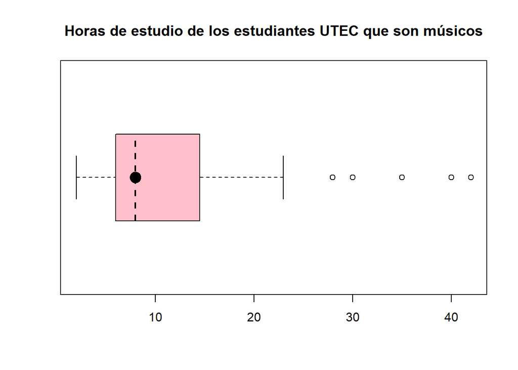

```r
boxplot(DATOS_TOCAN$horas_estudio, main="Horas de estudio de los estudiantes UTEC que son músicos", col="pink", medlty=2, medlwd=2, medpch=20, medcex = 3, horizontal = TRUE)
```

Es apreciable que el promedio es mayor que la mediana (12 > 8). Esto quiere decir que hay un sesgo hacia la derecha.

#### **Horas ocupadas para tocar instrumento a la semana**

```r
range(DATOS_TOCAN$horas_instrumento) #rango
```

```
## [1]  0 14
```

```r
round((sd(DATOS_TOCAN$horas_instrumento, na.rm = TRUE)/mean(DATOS_TOCAN$horas_instrumento))*100,2) #coeficiente de variación
```

```
## [1] 96.18
```

```r
round(sd(DATOS_TOCAN$horas_instrumento, na.rm = TRUE),2) #desviación estándar
```

```
## [1] 2.62
```

```r
#####var(TOCAN$horas_estudio, na.rm = TRUE) #variación
moda <- as.numeric(names(table(DATOS_TOCAN$horas_instrumento)[table(DATOS_TOCAN$horas_instrumento) == max(table(DATOS_TOCAN$horas_instrumento), na.rm = TRUE)]))
moda # MODA
```

```
## [1] 1
```

```r
DATOS_TOCAN %>% summarise_at('horas_instrumento', funs(mean,median,sd,min,max,IQR),na.rm=T)
```

| mean | median | sd | min | max | IQR |
| --- | --- | --- | --- | --- | --- |
| 2.723077 | 2 | 2.619087 | 0 | 14 | 3 |

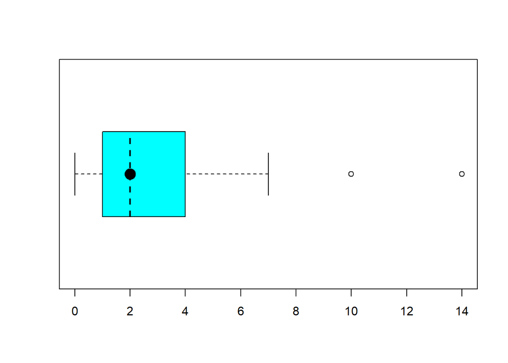

```r
boxplot(DATOS_TOCAN$horas_instrumento, col="cyan", medlty=2, medlwd=2, medpch=20, medcex = 3, horizontal = TRUE)
```

Es apreciable que el promedio es ligeramento mayor que la mediana (2.72 > 2). Esto quiere decir que hay un ligero sesgo hacia la derecha. (**sesgo positivo mínimo**)

#### Habilidad para tocar un tipo de instrumento

```r
range(DATOS_TOCAN$habilidad) #rango
```

```
## [1] 1 5
```

```r
round((sd(DATOS_TOCAN$habilidad, na.rm = TRUE)/mean(DATOS_TOCAN$habilidad))*100,2) #coeficiente de variación
```

```
## [1] 25.4
```

```r
round(sd(DATOS_TOCAN$habilidad, na.rm = TRUE),2) #desviación estándar
```

```
## [1] 0.77
```

```r
#####var(TOCAN$horas_estudio, na.rm = TRUE) #variación
moda <- as.numeric(names(table(DATOS_TOCAN$habilidad)[table(DATOS_TOCAN$habilidad) == max(table(DATOS_TOCAN$habilidad), na.rm = TRUE)]))
moda # MODA
```

```
## [1] 3
```

```r
DATOS_TOCAN %>% summarise_at('habilidad', funs(mean,median,sd,min,max,IQR),na.rm=T)
```

| mean | median | sd | min | max | IQR |
| --- | --- | --- | --- | --- | --- |
| 3.030769 | 3 | 0.7699276 | 1 | 5 | 0 |

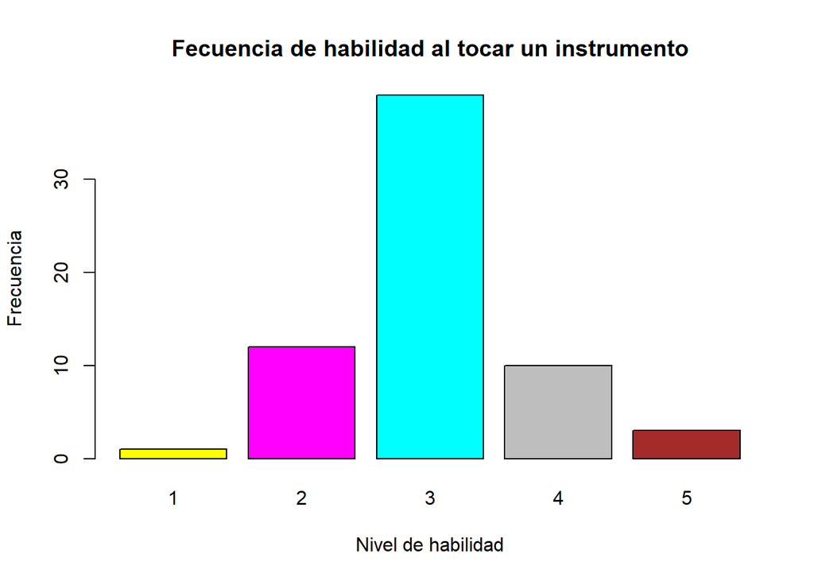

```r
barplot(table(DATOS_TOCAN$habilidad), main = "Fecuencia de habilidad al tocar un instrumento", xlab = "Nivel de habilidad", ylab = "Frecuencia", col=c("yellow","magenta","cyan","grey","brown"))
```

Es apreciable que el promedio es ligeramento mayor que la mediana (3.03 > 3). Esto quiere decir que hay un ligero sesgo hacia la derecha. (**sesgo positivo muy mínimo**)

#### Importancia de la música para aquellos que tocan instrumentos

```r
range(DATOS_TOCAN$importancia) #rango
```

```
## [1] 1 5
```

```r
round((sd(DATOS_TOCAN$importancia, na.rm = TRUE)/mean(DATOS_TOCAN$importancia))*100,2) #coeficiente de variación
```

```
## [1] 24.01
```

```r
round(sd(DATOS_TOCAN$importancia, na.rm = TRUE),2) #desviación estándar
```

```
## [1] 0.99
```

```r
#####var(TOCAN$horas_estudio, na.rm = TRUE) #variación
moda <- as.numeric(names(table(DATOS_TOCAN$importancia)[table(DATOS_TOCAN$importancia) == max(table(DATOS_TOCAN$importancia), na.rm = TRUE)]))
moda # MODA
```

```
## [1] 5
```

```r
DATOS_TOCAN %>% summarise_at('importancia', funs(mean,median,sd,min,max,IQR),na.rm=T)
```

| mean | median | sd | min | max | IQR |
| --- | --- | --- | --- | --- | --- |
| 4.107692 | 4 | 0.9862029 | 1 | 5 | 2 |

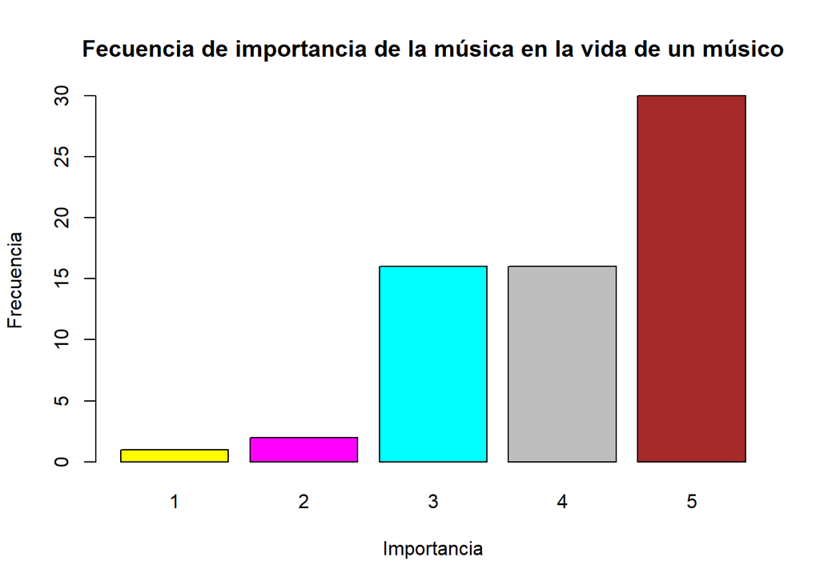

```r
barplot(table(DATOS_TOCAN$importancia), main = "Fecuencia de importancia de la música en la vida de un músico", xlab = "Importancia", ylab = "Frecuencia", col=c("yellow","magenta","cyan","grey","brown"))
```

#### Tiempo tocando instrumentos musicales

```r
range(DATOS_TOCAN$tiempo_tocando) #rango
```

```
## [1]  0 12
```

```r
round((sd(DATOS_TOCAN$tiempo_tocando, na.rm = TRUE)/mean(DATOS_TOCAN$tiempo_tocando))*100,2) #coeficiente de variación
```

```
## [1] 83.61
```

```r
round(sd(DATOS_TOCAN$tiempo_tocando, na.rm = TRUE),2) #desviación estándar
```

```
## [1] 3.05
```

```r
moda <- as.numeric(names(table(DATOS_TOCAN$tiempo_tocando)[table(DATOS_TOCAN$tiempo_tocando) == max(table(DATOS_TOCAN$tiempo_tocando), na.rm = TRUE)]))
moda # MODA
```

```
## [1] 2
```

```r
DATOS_TOCAN %>% summarise_at('tiempo_tocando',
                             funs(mean,median,sd,min,max,IQR),na.rm=T)
```

| mean | median | sd | min | max | IQR |
| --- | --- | --- | --- | --- | --- |
| 3.646154 | 3 | 3.048723 | 0 | 12 | 3 |

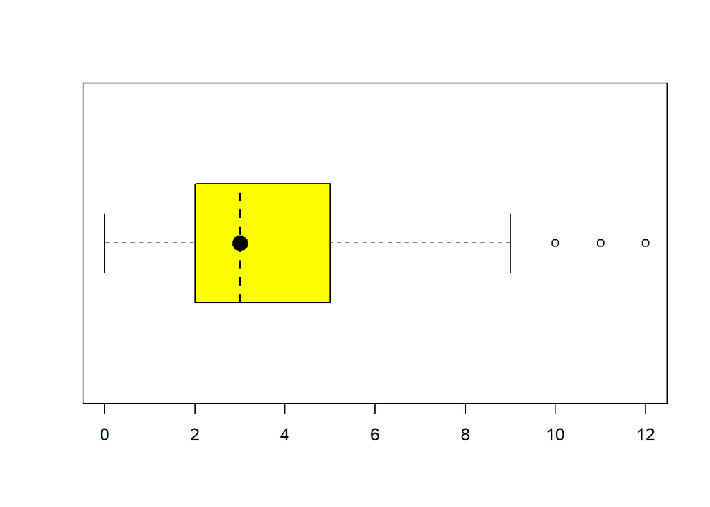

```r
boxplot(DATOS_TOCAN$tiempo_tocando, col="yellow", medlty=2, medlwd=2, medpch=20, medcex = 3, horizontal = TRUE)
```

Es apreciable que el promedio es ligeramento mayor que la mediana (3.65 > 3). Esto quiere decir que hay un ligero sesgo hacia la derecha. (**sesgo positivo mínimo**)

#### Correlación entre el tiempo tocando y que tan importante sea para aquel que toque.

HALLEMOS LA CORRELACIÓN entre el tiempo que una persona lleva tocando un tipo de instrumento musical y la importancia de la música en sus vidas.

```r
round(cor(DATOS_TOCAN$tiempo_tocando,DATOS_TOCAN$importancia, use = "complete.obs"),2)
```

```
## [1] 0.37
```

Una correlación de 0.37 indica que existe una relación que influye de manera positiva, es decir, mientras más tiempo toques más importante lo considerarás en tu vida.

## DESCRIPTORES NUMÉRICOS Y GRÁFICOS - NO TOCAN INSTRUMENTOS

Analizemos la tabla NO TOCAN INSTRUMENTOS y veamos que variables son numéricas y obtener información con el comando summary().

```r
summary(DATOS_NO_TOCAN)
```

```
##  tipo_musica        horas_estudio    horas_musica    importancia
##  Length:90          Min.   : 1.00   Min.   : 0.50   Min.   :1.000
##  Class :character   1st Qu.: 5.00   1st Qu.: 2.00   1st Qu.:3.000
##  Mode  :character   Median : 8.00   Median : 3.00   Median :4.000
##                     Mean   :10.38   Mean   : 4.95   Mean   :3.922
##                     3rd Qu.:10.75   3rd Qu.: 6.00   3rd Qu.:5.000
##                     Max.   :42.00   Max.   :23.00   Max.   :5.000
##  genero_relajacion  genero_motivacion  concentracion      animo
##  Length:90          Length:90          Min.   :1.000   Length:90
##  Class :character   Class :character   1st Qu.:2.000   Class :character
##  Mode  :character   Mode  :character   Median :4.000   Mode  :character
##                                        Mean   :3.344
##                                        3rd Qu.:4.000
##                                        Max.   :5.000
##     estres            momentos          beneficios
##  Length:90          Length:90          Length:90
##  Class :character   Class :character   Class :character
##  Mode  :character   Mode  :character   Mode  :character
##
##
##
```

Procedamos a mostrar los descriptores numéricos de nuestras 4 variables.

### Descriptores numéricos:

```r
range(DATOS_NO_TOCAN$horas_estudio) #rango
```

```
## [1]  1 42
```

```r
round((sd(DATOS_NO_TOCAN$horas_estudio, na.rm = TRUE)/mean(DATOS_NO_TOCAN$horas_estudio))*100,2) #coeficiente de variación
```

```
## [1] 89.27
```

```r
round(sd(DATOS_NO_TOCAN$horas_estudio, na.rm = TRUE),2) #desviación estándar
```

```
## [1] 9.26
```

```r
moda <- as.numeric(names(table(DATOS_NO_TOCAN$horas_estudio)[table(DATOS_NO_TOCAN$horas_estudio) == max(table(DATOS_NO_TOCAN$horas_estudio), na.rm = TRUE)]))
moda # MODA
```

```
## [1]  8 10
```

```r
DATOS_NO_TOCAN %>% summarise_at('horas_estudio', funs(mean,median,sd,min,max,IQR),na.rm=T)
```

| mean | median | sd | min | max | IQR |
| --- | --- | --- | --- | --- | --- |
| 10.37778 | 8 | 9.264621 | 1 | 42 | 5.75 |

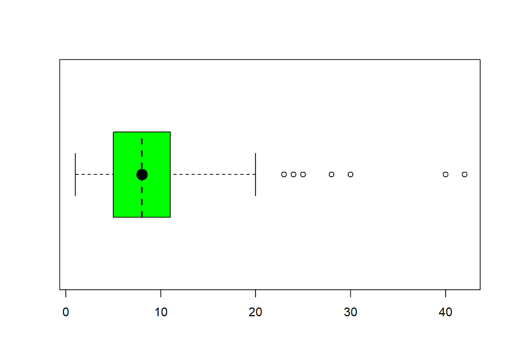

```r
boxplot(DATOS_NO_TOCAN$horas_estudio, col="green", medlty=2, medlwd=2, medpch=20, medcex = 3, horizontal = TRUE)
```

Es apreciable que el promedio es mayor que la mediana (10.38 > 8). Esto quiere decir que hay un sesgo hacia la derecha. (**sesgo positivo**)

```r
range(DATOS_NO_TOCAN$horas_musica) #rango
```

```
## [1]  0.5 23.0
```

```r
round((sd(DATOS_NO_TOCAN$horas_musica, na.rm = TRUE)/mean(DATOS_NO_TOCAN$horas_musica))*100,2) #coeficiente de variación
```

```
## [1] 99.43
```

```r
round(sd(DATOS_NO_TOCAN$horas_estudio, na.rm = TRUE),2) #desviación estándar
```

```
## [1] 9.26
```

```r
moda <- as.numeric(names(table(DATOS_NO_TOCAN$horas_musica)[table(DATOS_NO_TOCAN$horas_musica) == max(table(DATOS_NO_TOCAN$horas_musica), na.rm = TRUE)]))
moda # MODA
```

```
## [1] 2
```

```r
DATOS_NO_TOCAN %>% summarise_at('horas_musica', funs(mean,median,sd,min,max,IQR),na.rm=T)
```

| mean | median | sd | min | max | IQR |
| --- | --- | --- | --- | --- | --- |
| 4.95 | 3 | 4.92189 | 0.5 | 23 | 4 |

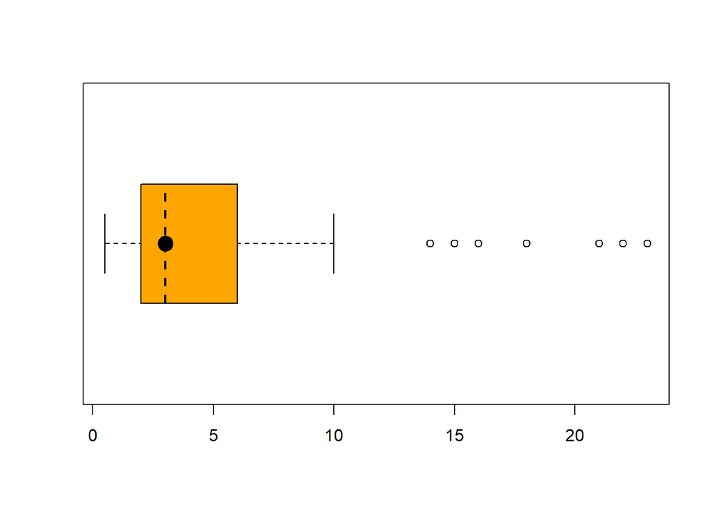

```r
boxplot(DATOS_NO_TOCAN$horas_musica, col="orange", medlty=2, medlwd=2, medpch=20, medcex = 3, horizontal = TRUE)
```

Es apreciable que el promedio es mayor que la mediana (4.95 > 3). Esto quiere decir que hay un sesgo hacia la derecha. (**sesgo positivo**)

```r
range(DATOS_NO_TOCAN$importancia) #rango
```

```
## [1] 1 5
```

```r
round((sd(DATOS_NO_TOCAN$importancia, na.rm = TRUE)/mean(DATOS_NO_TOCAN$importancia))*100,2) #coeficiente de variación
```

```
## [1] 28.66
```

```r
round(sd(DATOS_NO_TOCAN$importancia, na.rm = TRUE),2) #desviación estándar
```

```
## [1] 1.12
```

```r
moda <- as.numeric(names(table(DATOS_NO_TOCAN$importancia)[table(DATOS_NO_TOCAN$importancia) == max(table(DATOS_NO_TOCAN$importancia), na.rm = TRUE)]))
moda # MODA
```

```
## [1] 5
```

```r
DATOS_NO_TOCAN %>% summarise_at('importancia', funs(mean,median,sd,min,max,IQR),na.rm=T)
```

| mean | median | sd | min | max | IQR |
| --- | --- | --- | --- | --- | --- |
| 3.922222 | 4 | 1.124075 | 1 | 5 | 2 |

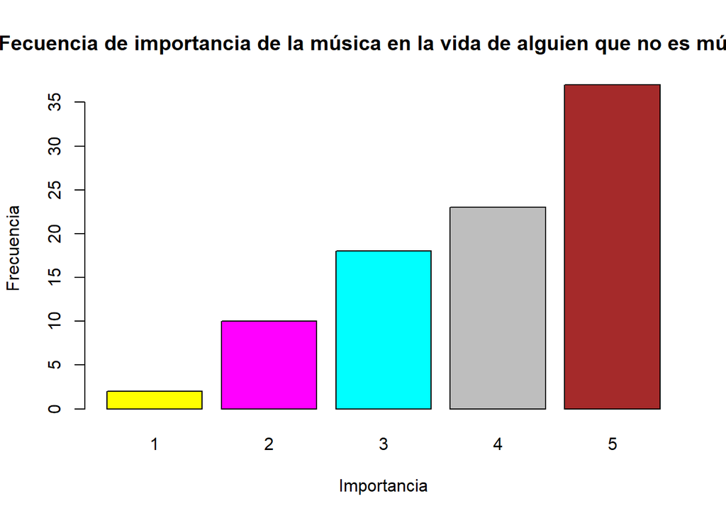

```r
barplot(table(DATOS_NO_TOCAN$importancia), main = "Fecuencia de importancia de la música en la vida de alguien que no es músico", xlab = "Importancia", ylab = "Frecuencia", col=c("yellow","magenta","cyan","grey","brown"))
```

También podemos apreciar que aquellos que tocan instrumentoss son más propensos a considerar importante la música para ellos frente aquellos que no tocan.

```r
range(DATOS_NO_TOCAN$concentracion) #rango
```

```
## [1] 1 5
```

```r
round((sd(DATOS_NO_TOCAN$concentracion, na.rm = TRUE)/mean(DATOS_NO_TOCAN$concentracion))*100,2) #coeficiente de variación
```

```
## [1] 37.54
```

```r
round(sd(DATOS_NO_TOCAN$concentracion, na.rm = TRUE),2) #desviación estándar
```

```
## [1] 1.26
```

```r
#####var(TOCAN$horas_estudio, na.rm = TRUE) #variación
moda <- as.numeric(names(table(DATOS_NO_TOCAN$concentracion)[table(DATOS_NO_TOCAN$concentracion) == max(table(DATOS_NO_TOCAN$concentracion), na.rm = TRUE)]))
moda # MODA
```

```
## [1] 4
```

```r
DATOS_NO_TOCAN %>% summarise_at('concentracion', funs(mean,median,sd,min,max,IQR),na.rm=T)
```

| mean | median | sd | min | max | IQR |
| --- | --- | --- | --- | --- | --- |
| 3.344444 | 4 | 1.255649 | 1 | 5 | 2 |

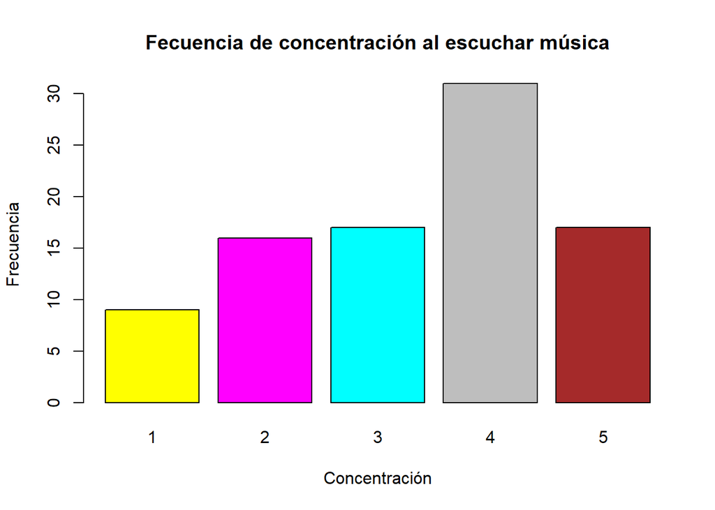

```r
barplot(table(DATOS_NO_TOCAN$concentracion), main = "Fecuencia de concentración al escuchar música", xlab = "Concentración", ylab = "Frecuencia", col=c("yellow","magenta","cyan","grey","brown"))
```

Es apreciable que el promedio es ligeramento menor que la mediana (3.34 < 4). Esto quiere decir que hay un ligero sesgo hacia la izquierda (**sesgo negativo mínimo**)

### Más decriptores

#### Comprobando correlación entre importancia y tiempo tocando instrumentos.

```r
# Definimos función de correlación
calcular_correlacion <- function(variable1, variable2) {
  # Calculamos el coeficiente de correlación
  cor <- cor(variable1, variable2,use = "complete.obs")
  print(cor)
  if (abs(cor) >= 0.7) {
    print("La relación es fuerte")
  } else if (abs(cor) >= 0.3) {
    print("La relación es moderada")
  } else {
    print("La relación es débil")
  }
}
```

```r
calcular_correlacion(DATOS_TOCAN$importancia, DATOS_TOCAN$tiempo_tocando)
```

```
## [1] 0.3662543
## [1] "La relación es moderada"
```

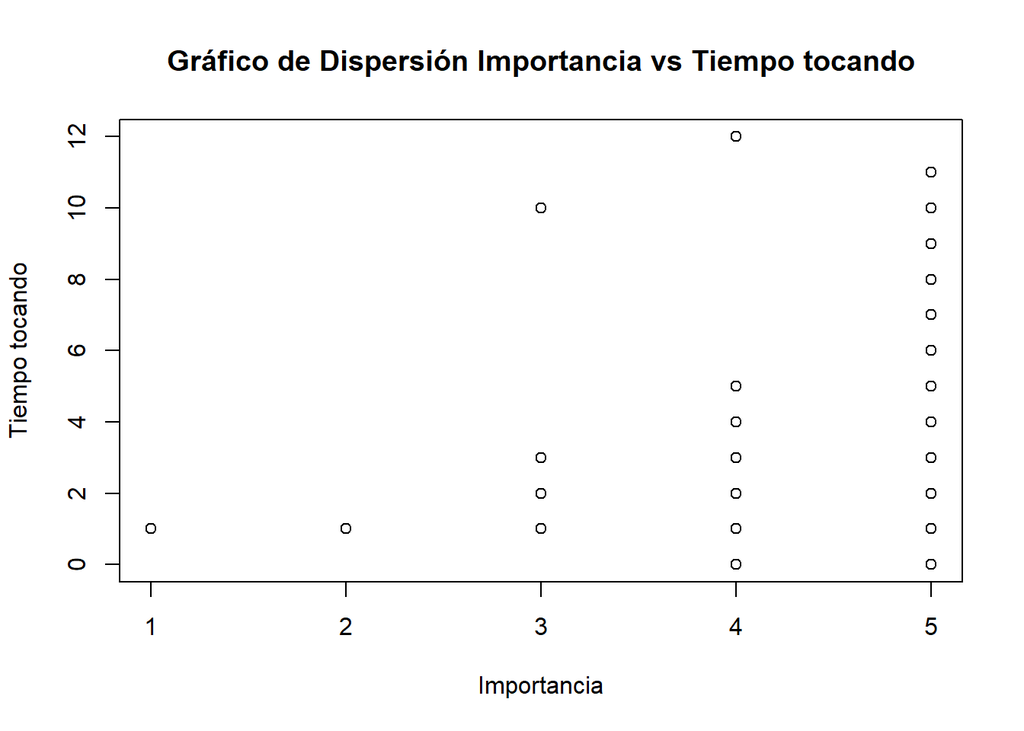

```r
plot(DATOS_TOCAN$importancia, DATOS_TOCAN$tiempo_tocando, xlab = "Importancia", ylab = "Tiempo tocando", main = "Gráfico de Dispersión Importancia vs Tiempo tocando")
```

## Descriptores de los datos de entrada

Primero que todo sería interesante ver qué cantidad de nuestro espacio muestral toca instrumento. Esto con la finalidad de darnos una idea, de acuerdo a nuestra muestra, qué porcentaje de personas tocan instrumento en UTEC.

```r
table(DATOS$tocan_instrumentos)
```

```
##
## No Sí
## 90 65
```

```r
round(min(table(DATOS$tocan_instrumentos))/nrow(DATOS), 2) * 100
```

```
## [1] 42
```

Esto significa que el 42% de toda nuestra muestra sí toca algún tipo de instrumento, lo que llama muchísimo la atención. Uno esperaría que las personas que tocan sean muchísimas menos. Ahora podríamos encontrar la relación entre el sexo y saber si tocan o no instrumentos. Esto se hará mediante un mosaico para que sean visibles las proporciones.

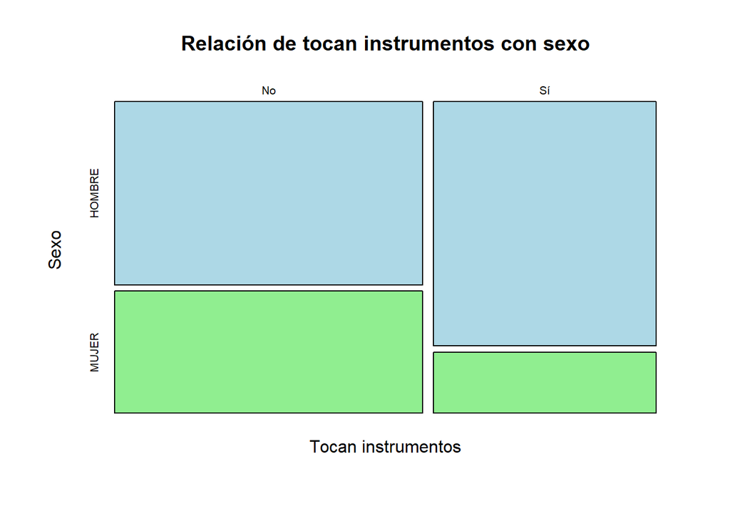

```r
mosaicplot(DATOS$tocan_instrumentos ~ DATOS$sexo
           , main = "Relación de tocan instrumentos con sexo"
           , xlab = "Tocan instrumentos"
           , ylab = "Sexo"
           , color = c("lightblue", "lightgreen")
           )
```

De este mosaico se extraen algunas cosas:

La primera es que, en proporción, tenemos más hombres en nuestra muestra que mujeres. Por lo que, independientemente de si tocan o no tocan instrumento, la proporción de hombres en ambos casos es mayor.

#### Relación entre la salud mental y como sienten las personas que tocan instrumentos musicales

Procederemos a relacionar el sentimiento de alguien que al tocar un instrumeto musical y si esto afecta su salud mental en la tabla `TOCAN`. Tal vez podamos encontrar alguna relación directa entre estas dos. Por lo que haremos un gráfico de barras.

```r
table(DATOS_TOCAN$salud_mental)
```

```
##
##               Es importante Es moderadamente importante
##                          21                          12
##           Es muy importante          Es poco importante
##                          31                           1
```

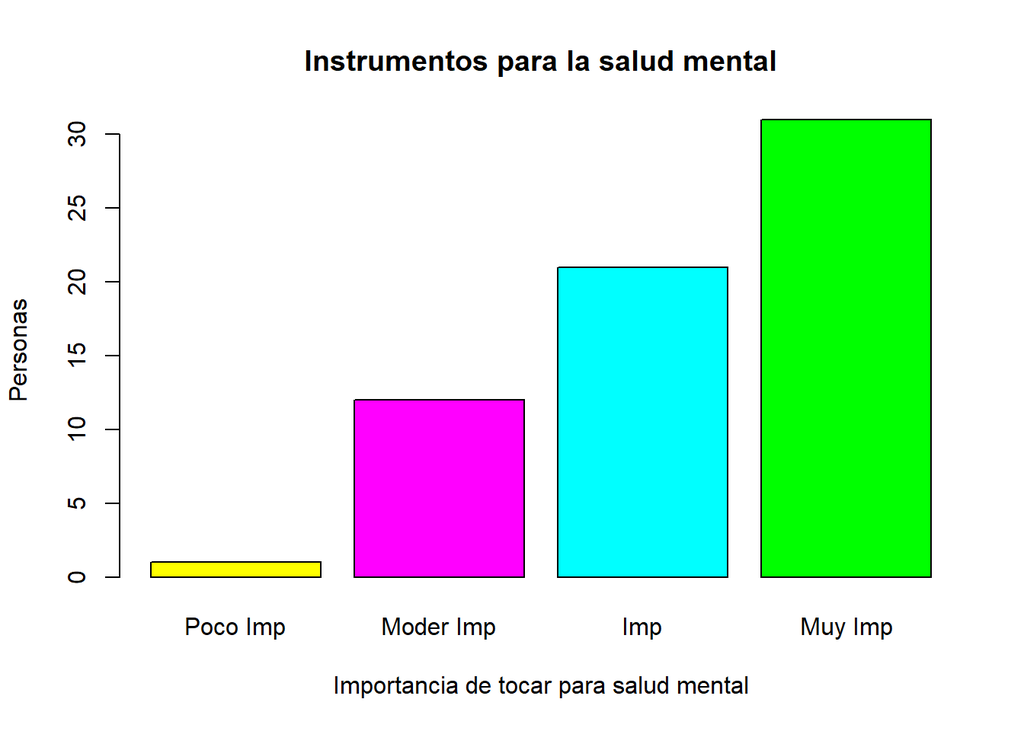

```r
barplot(sort(table(DATOS_TOCAN$salud_mental))
        , main = "Instrumentos para la salud mental"
        , names.arg = c("Poco Imp", "Moder Imp", "Imp", "Muy Imp")
        , xlab = "Importancia de tocar para salud mental"
        , ylab = "Personas"
        , col=c("yellow","magenta","cyan","green")
        )
```

```r
table(DATOS_TOCAN$sentimiento)
```

```
##
## Me siento concentrado/a y en un estado de fluidez.
##                                                 17
##       Me siento emocionado/a y lleno/a de energía.
##                                                 11
##                      Me siento feliz y relajado/a.
##                                                 35
##          Me siento frustrado/a y con dificultades.
##                                                  1
##               Me siento indiferente o sin emoción.
##                                                  1
```

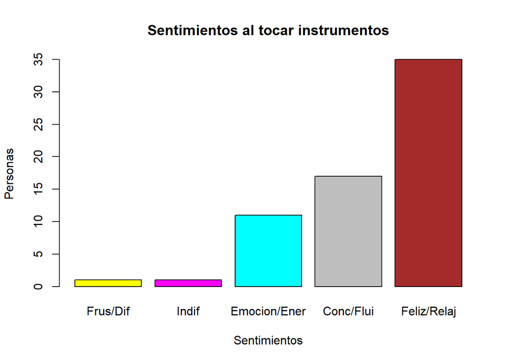

```r
barplot(sort(table(DATOS_TOCAN$sentimiento))
        , main = "Sentimientos al tocar instrumentos"
        , names.arg = c("Frus/Dif", "Indif", "Emocion/Ener", "Conc/Flui", "Feliz/Relaj")
        , xlab = "Sentimientos"
        , ylab = "Personas"
        , col=c("yellow","magenta","cyan","grey","brown")
        )
```

Además sienten cosas positivas al estar tocando instrumentos. Esto es una clara prueba de que tocar instrumentos puede traer, en su mayoría, cosas positivas para nosotros los estudiantes. Ya sea como un medio de distracción de la vida ajetreada y de presión en la que se vive, y también para volver luego a los estudios con muchísimas más ganas.

```r
table(DATOS_TOCAN$tiempo_tocando)
```

```
##
##  0  1  2  3  4  5  6  7  8  9 10 11 12
##  3 12 15 14  4  4  2  1  2  2  3  2  1
```

Realizemos un gráfico de puntos para ver la relación entre la habilidad que cree tener cada uno según el tiempo que lleva tocando ese tipo de instrumento.

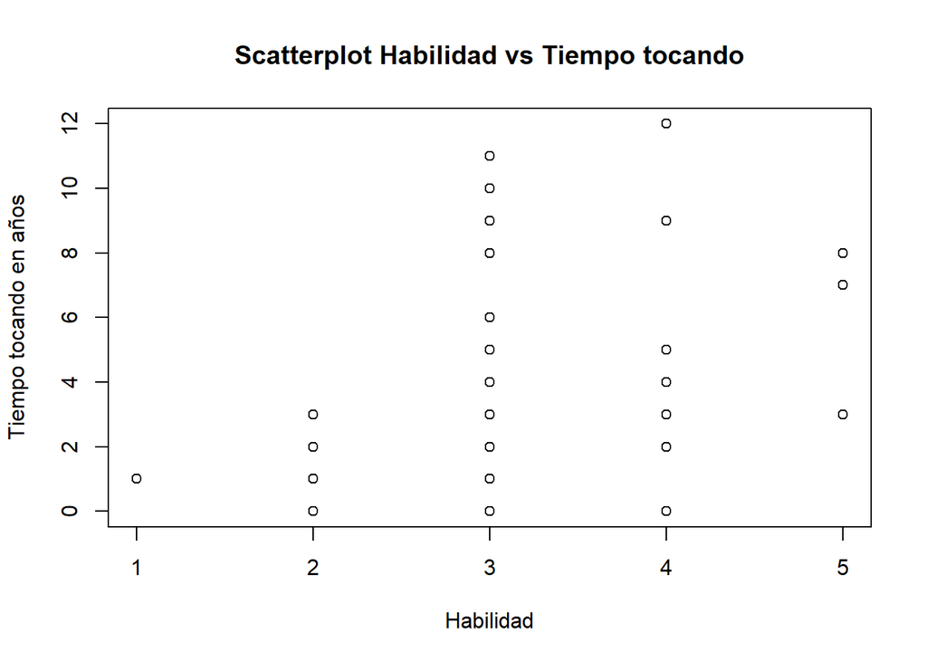

```r
# Ejemplo de gráfico de dispersión
plot(DATOS_TOCAN$habilidad, DATOS_TOCAN$tiempo_tocando, main = "Scatterplot Habilidad vs Tiempo tocando", xlab="Habilidad", ylab="Tiempo tocando en años")
```